# Tugas Pertemuan 2 MPDW

Anis Sulistiyowati - G1401211084

2023-09-10

# *Packages*

```r
library(dplyr)
library(TTR)
library(forecast)
library(lmtest) #uji formal pendeteksian autokorelasi
library(orcutt) #membuat model regresi Cochrane-Orcutt
library(HoRM) #membuat model regresi Hildreth-Lu
```

# Input Data

Sumber data : https://www.kaggle.com/datasets/jarredpriester/california-wine-production-19802020 Data yang digunakan merupakan data Produksi Anggur California 1980-2020 khususnya di Kota Alameda

```r
library(rio)
data <- import("https://raw.githubusercontent.com/Anissls333/mpdw/main/pertemuan%202/data2.csv")
View(data)
```

# Penyiapan data

```r
#Membuat peubah periode
Periode = seq(from = 1, to = 41, by = 1)

#Menggabungkan semua peubah ke dalam satu data frame
df = data.frame(Periode, data)
df
```

```
##    Periode Production Value.Dollars. Yield.Unit.Acre.
## 1        1       3918        2125000             2.36
## 2        2       4860        2662000             2.82
## 3        3       6326        3342000             3.93
## 4        4       5042        2137000             3.07
## 5        5       5286        2103000             3.16
## 6        6       5336        1802000             3.55
## 7        7       4908        1749000             3.35
## 8        8       5006        1794000             3.43
## 9        9       4094        1548000             3.37
## 10      10       7615        5432000             4.20
## 11      11       3435        3023000             2.11
## 12      12       4938        4282000             3.84
## 13      13       5028        4474000             3.28
## 14      14       4248        3626000             2.70
```

[output cut: 27 more lines]

# Eksplorasi Data

```r
#Matriks korelasi antar peubah
library(tidyverse)
```

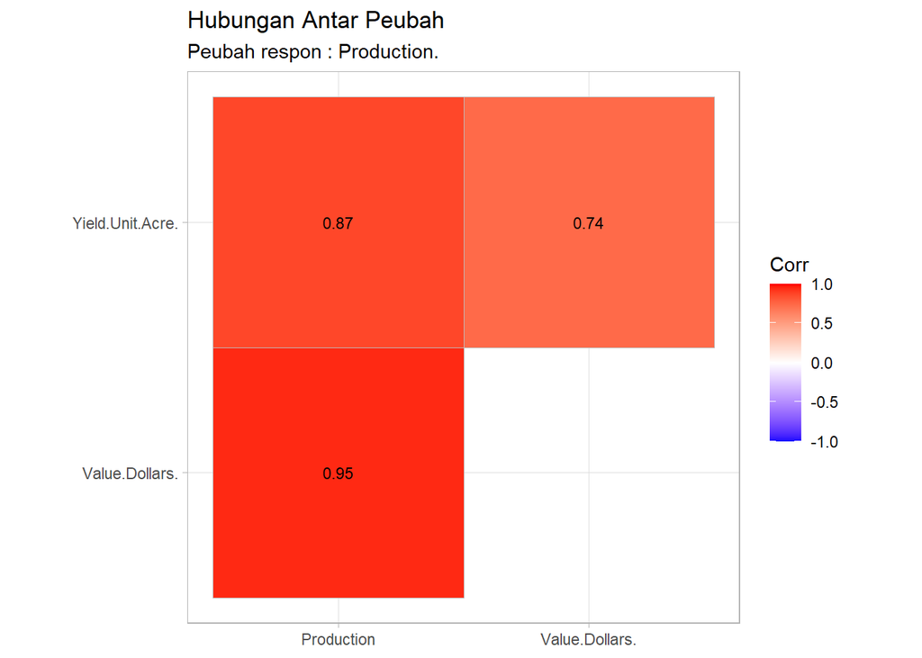

```r
df %>%
  as_tibble() %>%
  select(-Periode) %>%
  cor() %>%
  ggcorrplot::ggcorrplot(type = "upper", lab = TRUE, lab_size = 3) +
  theme_light() +
  labs(title = "Hubungan Antar Peubah",
       subtitle = "Peubah respon : Production.",
       x = NULL, y = NULL)
```

# Pembentukan Penduga Model Regresi

```r
model_wine = lm(Production~Value.Dollars.+Yield.Unit.Acre., data=df)
summary(model_wine)
```

```
##
## Call:
## lm(formula = Production ~ Value.Dollars. + Yield.Unit.Acre.,
##     data = df)
##
## Residuals:
##      Min       1Q   Median       3Q      Max
## -1635.64  -657.32    90.89   432.82  2392.20
##
## Coefficients:
##                    Estimate Std. Error t value Pr(>|t|)
## (Intercept)      -4.254e+02  5.314e+02  -0.800    0.428
## Value.Dollars.    3.932e-04  2.937e-05  13.385 5.83e-16 ***
## Yield.Unit.Acre.  1.384e+03  1.848e+02   7.492 5.37e-09 ***
## ---
## Signif. codes:  0 '***' 0.001 '**' 0.01 '*' 0.05 '.' 0.1 ' ' 1
##
## Residual standard error: 832.5 on 38 degrees of freedom
## Multiple R-squared:  0.9577, Adjusted R-squared:  0.9555
## F-statistic: 430.2 on 2 and 38 DF,  p-value: < 2.2e-16
```

Model yang dihasilkan adalah
$$Production=-(4.254e+02)+(3.932e-04)Value.Dollars.+(1.384e+03)
Yield.Unit.Acre.$$
Dari hasil ringkasan model diperoleh beberapa informas: 1. Uji F $p-value = (2.2e-16) < \alpha= 5% (Tolak H_0)$ Artinya: Minimal terdapat satu peubah penjelas yang berpengaruh signifikanterhadap `Production` pada taraf 5%

2. Uji t Hasil uji-t parsial parameter regresi koefisien regresi `Value.Dollars.dan Yield.Unit.Acre.` juga menunjukkan hal yang sama, yaitu memiliki *p-value* < $\alpha$ (5%) sehingga nyata dalam taraf 10%.
3. $R^2=0.9555$ Artinya, sebesar 95.55% keragaman nilai Production dapat dijelaskan oleh model yang telah dibentuk. Hasil ini menunjukkan hasil yang bagus, seolah mendapatkan hasil terbaik.

Tetapi, tetap memerlukan pengujian asumsi.

# Pengujian Asumsi

## 1. Uji Multikolinearitas

```r
car::vif(model_wine)
```

```
##   Value.Dollars. Yield.Unit.Acre.
##         2.238017         2.238017
```

`Nilai VIF` pada kedua peubah penjelas < 10. Sehingga tidak terjadi multikolinearitas pada kedua peubah penjelas tersebut.

## 2. Sisaan menyebar normal

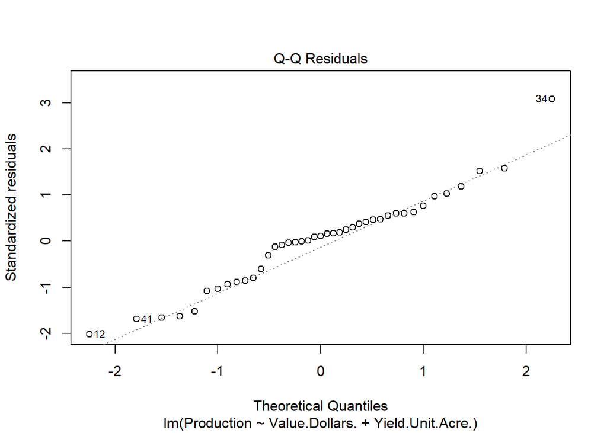

```r
plot(model_wine, 2);
```

Dari QQ-Plot tersebut terlihat bahwa titik-titiknya cenderung mengikuti garis kenormalan. Sehingga dapat disimpulkan bahwa sisaan menyebar normal.

## 3. Nilai harapan sisaan sama dengan nol

$H_0 : E[\varepsilon]=0$ $H_1 : E[\varepsilon]\ne0$

```r
# Uji t
t.test(resid(model_wine), mu = 0,)
```

```
##
##  One Sample t-test
##
## data:  resid(model_wine)
## t = 6.4321e-17, df = 40, p-value = 1
## alternative hypothesis: true mean is not equal to 0
## 95 percent confidence interval:
##  -256.1088  256.1088
## sample estimates:
##    mean of x
## 8.150662e-15
```

$p-value=1 > 0.1$ (tak tolak $H_0$), artinya nilai harapan sisaan sama dengan nol

## 4. Ragam sisaan homogen

$H_0: Var[\varepsilon]=\sigma^2I$ $H_1: Var[\varepsilon]\ne \sigma^2I$

```r
# Uji Breusch-Pagan
lmtest::bptest(model_wine)
```

```
##
##  studentized Breusch-Pagan test
##
## data:  model_wine
## BP = 8.3142, df = 2, p-value = 0.01565
```

Namun, tidak akan dilakukan penanganan untuk keadaan tak standar ini, karena hanya berfokus pada penanganan autokorelasi.

## 5. Deteksi autokorelasi (tidak terjadi autokorelasi)

$H_0 : Cov[\varepsilon_i,\varepsilon_j]=0$ (tidak terjadi autokorelasi pada sisaan) $H_0 : Cov[\varepsilon_i,\varepsilon_j]\neq0$ (terjadi autokorelasi pada sisaan)

```r
# Uji Durbin Watson
library(lmtest)
dwtest(model_wine)
```

```
##
##  Durbin-Watson test
##
## data:  model_wine
## DW = 1.4495, p-value = 0.02169
## alternative hypothesis: true autocorrelation is greater than 0
```

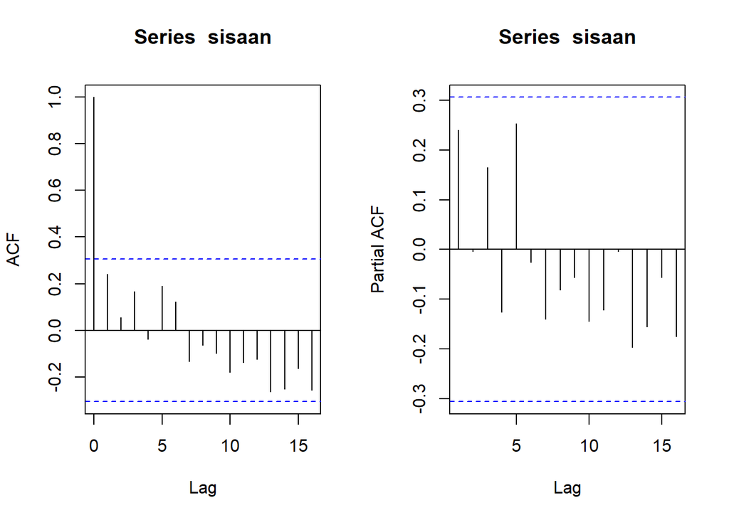

```r
#ACF dan PACF identifikasi autokorelasi
sisaan = model_wine$residuals
par(mfrow = c(1,2))
acf(sisaan)
pacf(sisaan)
```

$p-value=0.02169 < 0.1$ (tolak $H_0$), artinya terjadi autkorelasi pada sisaan pada taraf `5%`

Perlu penanganan keadaan tak standar karena terjadi autokorelasi.

## Penanganan Keadaan Tak Standar

### Penanganan Autokorelasi

#### 1. Metode Cochrane-Orcutt

Penanganan metode Cochrane-Orcutt dapat dilakukan dengan bantuan packages Orcutt pada aplikasi `R` maupun secara manual.

```r
library(orcutt)
model_co <-cochrane.orcutt(model_wine)
model_co
```

```
## Cochrane-orcutt estimation for first order autocorrelation
##
## Call:
## lm(formula = Production ~ Value.Dollars. + Yield.Unit.Acre.,
##     data = df)
##
##  number of interaction: 7
##  rho 0.27034
##
## Durbin-Watson statistic
## (original):    1.44945 , p-value: 2.169e-02
## (transformed): 1.91487 , p-value: 3.463e-01
##
##  coefficients:
##      (Intercept)   Value.Dollars. Yield.Unit.Acre.
##      -462.163061         0.000403      1365.054164
```

```r
dwtest(model_co)
```

```
##
##  Durbin-Watson test
##
## data:  model_co
## DW = 1.9149, p-value = 0.3463
## alternative hypothesis: true autocorrelation is greater than 0
```

Model regresi setelah dilakukan penanganan
$$Production = -462.163061 + 0.000403
Value.Dollars. + 1365.054164 Yield.Unit.Acre.$$
Nilai DW dan *p-value* meningkat menjadi $1.9149$ dan $0.3463$. Nilai DW sudah berada pada rentang DU < DW < 4-DU (DU = $1.60307$) dan nilai *p-value* > 0.05, artinya belum cukup bukti untuk menyatakan bahwa sisaan terdapat autokorelasi pada taraf nyata 5%. Untuk nilai $ρ ̂$ optimum yang digunakan adalah $0.27034$.

```r
#Rho optimum
rho <- model_co$rho
rho
```

```
## [1] 0.2703401
```

### Transformasi secara manual

```r
#Transformasi Manual
Production.trans <- df$Production[-1]-df$Production[-41]*rho
Yield.trans <- df$Yield.Unit.Acre.[-1]-df$Yield.Unit.Acre.[-41]*rho
Value.trans <- df$Value.Dollars.[-1]-df$Value.Dollars.[-41]*rho
model_comanual<- lm(Production.trans~Value.trans+Yield.trans)
summary(model_comanual)
```

```
##
## Call:
## lm(formula = Production.trans ~ Value.trans + Yield.trans)
##
## Residuals:
##     Min      1Q  Median      3Q     Max
## -1909.8  -371.5    34.8   460.6  2165.8
##
## Coefficients:
##               Estimate Std. Error t value Pr(>|t|)
## (Intercept) -3.372e+02  4.090e+02  -0.824    0.415
## Value.trans  4.029e-04  3.407e-05  11.825 3.93e-14 ***
## Yield.trans  1.365e+03  1.849e+02   7.381 8.85e-09 ***
## ---
## Signif. codes:  0 '***' 0.001 '**' 0.01 '*' 0.05 '.' 0.1 ' ' 1
##
## Residual standard error: 815.1 on 37 degrees of freedom
## Multiple R-squared:  0.9388, Adjusted R-squared:  0.9355
## F-statistic: 283.9 on 2 and 37 DF,  p-value: < 2.2e-16
```

```r
#Mencari Penduga Koefisien Regresi setelah Transformasi ke Persamaan Awal
b0bintang <- model_comanual$coefficients[-c(2,3)]
b0 <- b0bintang/(1-rho)
b1 <- model_comanual$coefficients[-c(1,3)]
b2 <- model_comanual$coefficients[-c(1,2)]
b0
```

```
## (Intercept)
##   -462.1631
```

```r
b1
```

```
##  Value.trans
## 0.0004029072
```

```r
b2
```

```
## Yield.trans
##    1365.054
```

Hasil perhitungan koefisien regresi tersebut menghasilkan hasil yang sama dengan model yang dihasilkan menggunakan *packages*.

```r
#Model yang dihasilkan menggunakan packages
model_co
```

```
## Cochrane-orcutt estimation for first order autocorrelation
##
## Call:
## lm(formula = Production ~ Value.Dollars. + Yield.Unit.Acre.,
##     data = df)
##
##  number of interaction: 7
##  rho 0.27034
##
## Durbin-Watson statistic
## (original):    1.44945 , p-value: 2.169e-02
## (transformed): 1.91487 , p-value: 3.463e-01
##
##  coefficients:
##      (Intercept)   Value.Dollars. Yield.Unit.Acre.
##      -462.163061         0.000403      1365.054164
```